# ORBIS Roman World transport network centrality measures

Antonio Rivero Ostoic

CEDHAR, Aarhus University

jaro@cas.au.dk

14 September 2021 (update: 22-09-21)

## ORBIS transport network

This post concerns network centrality measures from ORBIS:

Scheidel, W. and Meeks, E. (May 2, 2012). ORBIS: The Stanford Geospatial Network Model of the Roman World. Retrieved 14 Sep, 2021, from http://orbis.stanford.edu.

The ORBIS transport network of the Roman Empire has a set of nodes representing settlements and crossing points with coordinates, and a set of edges as edgelist with the type of connection and transportation costs.

```r
# retrieve Orbis dataset from public repository
orbis=read.csv(curl::curl("https://stacks.stanford.edu/file/druid:mn425tz9757/orbis_nodes_0514.csv"),head=TRUE)
orbise=read.csv(curl::curl("https://stacks.stanford.edu/file/druid:mn425tz9757/orbis_edges_0514.csv"),head=TRUE)
```

```r
head(orbis)
```

```
     id           label      x      y
1 50002   Ad fl. Tigrim 37.325 42.196
2 50209 Iulia Concordia 45.757 12.844
3 50327            Roma 41.892 12.486
4 50319      Praetorium 31.500 15.500
5 50294        Patavium 45.410 11.877
6 50322         Puteoli 40.824 14.122
```

```r
head(orbise)
```

```
  source target      km  days expense type
1  50001  50056  54.539 1.818   1.909 road
2  50001  50100  50.135 1.671   1.755 road
3  50001  50293  65.681 2.189   2.299 road
4  50001  50473 225.368 7.512   7.888 road
5  50002  50275  92.174 3.072   3.226 road
6  50003  50052 109.155 3.639   3.820 road
```

### Adjacency matrix

Network connections in ORBIS are based on travel *expenses* located in the fifth column of `orbise` data frame, while the two first columns of `orbise` records the edgelist with *ids*.

```r
orbisnet <- multiplex::read.srt(orbise[,c(1,2,5)], header=TRUE)
```

Since travel expenses is valued data, we need to dichotomize the network with the minimum weight as cut-off value.

```r
# dichotomize
orbisdnet <- multiplex::dichot(orbisnet, c=min(orbisnet[orbisnet>0]))
```

### Graph

`"multigraph"` allows visualizing the ORBIS transport network of the Roman Empire as a valued graph.

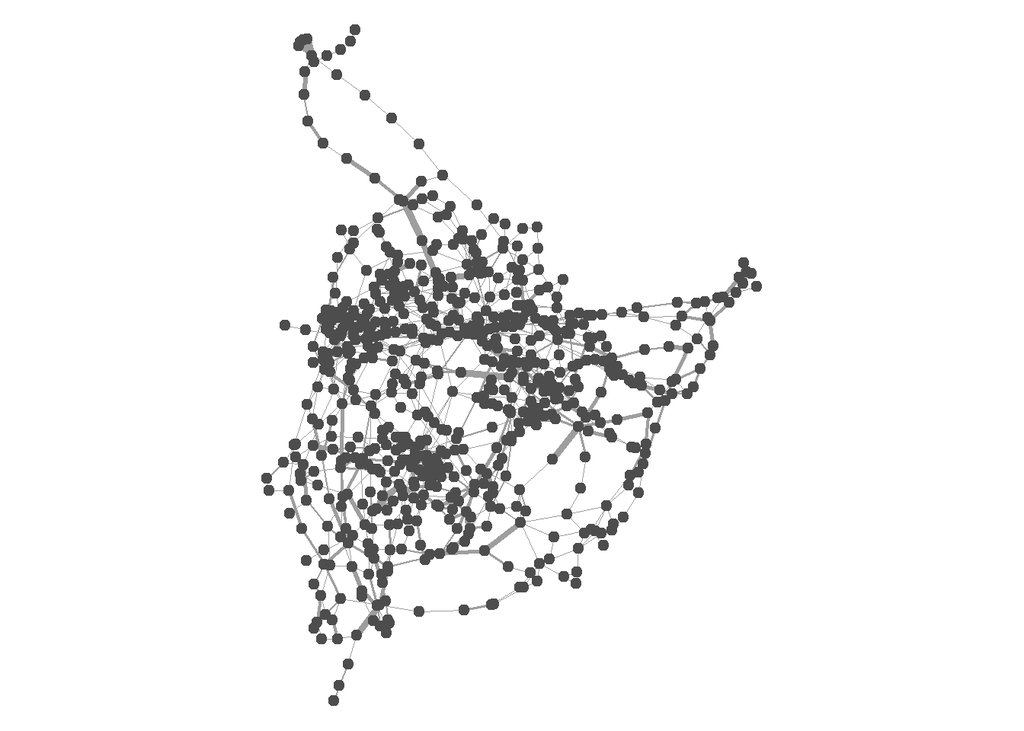

Graph of ORBIS transport network

```r
multigraph::multigraph(orbisnet, layout="force", seed=123, directed=FALSE, valued=TRUE, showLbs=FALSE, ecol=8)
```

## Network centrality

Network centrality measures are to define which are the most important or central entities in the network.

### Centrality measures based on neighbours

#### Degree centrality

**Degree centrality** measures a node’s importance based on the number of neighbours.

Compute degree centrality by column sum in the adjacency matrix `orbisdnet`. Since the ORBIS transport network is undirected, in-degree and out-degree centralities are indistinguishable, and row sum leads to the same result.

```r
# to compute outdegree centrality
orbisdnetdc <- colSums(orbisdnet)
# replace id by label
names(orbisdnetdc) <- orbis[match(as.numeric(names(orbisdnetdc)), orbis$id),2]
```

And look at prominent nodes in the graph representing the Roman Empire transportation network.

```r
# 12 most prominent nodes with degree centrality
require("magrittr")
orbisdnetdc %>%
  sort(decreasing=TRUE) %>%
  head(12)
```

```
            Delos            Rhodos          Carthago      Ostia/Portus         Lilybaeum
               21                20                11                10                10
             Roma            Paphos    Portus Pachyni           Messana Apollonia-Sozousa
                9                 9                 9                 9                 9
            Samos  Constantinopolis
                9                 8
```

(❌ for example, `Ratae` is not reported in ORBIS transport network with high degree centrality.)

#### Eigenvector centrality

Another centrality measure based on neighbours is **eigenvector centrality**, which measures a node’s importance while considering the number and importance of its neighbours.

There are several packages in `R` to compute network centrality measures.

The following examples is for the dichotomized transport network recorded in `orbisdnet`, and it uses `"igraph"` `R` package

- [https://CRAN.R-project.org/package=igraph](https://cran.r-project.org/package=igraph).

```r
# compute eigenvector centrality (3 decimals)
orbisdnetec <- orbisdnet %>%
  igraph::graph.adjacency() %>%
  igraph::eigen_centrality() %>%
  use_series("vector") %>%
  sort(decreasing=TRUE) %>%
  round(3) %>%
  as.vector(mode="list")
```

```r
# ids by labels
names(orbisdnetec) <- as.vector(orbis[match(as.numeric(names(orbisdnetec)), orbis$id),2])
```

Prominent nodes in terms of eigenvector centrality.

```r
# 10 nodes with highest eigenvector scores
require("magrittr")
orbisdnetec %>%
  head(10) %>%
  unlist()
```

```
     Rhodos       Delos       Samos         Kos     Ephesus      Myndos  Astypaleia     Amorgos
      1.000       0.953       0.588       0.583       0.514       0.434       0.414       0.414
Sounion Pr.    Selinous
      0.397       0.371
```

### Centrality measures based on shortest path

Besides neighbours, centrality measures on networks are also based on geodesic or shortest path.

#### Betweenness centrality

**Betweenness centrality** measures the fraction of shortest paths between all other nodes that run through the node.

```r
# compute betweenness centrality
require("magrittr")
orbisdnetbc <- orbisdnet %>%
  igraph::graph.adjacency() %>%
  igraph::betweenness() %>%
  sort(decreasing=TRUE) %>%
  as.vector(mode="list")
```

```r
# ids by labels
names(orbisdnetbc) <- as.vector(orbis[match(as.numeric(names(orbisdnetbc)), orbis$id),2])
```

Then look at prominent nodes in terms of betweenness centrality.

```r
# 10 nodes with highest betweenness scores
require("magrittr")
orbisdnetbc %>%
  head(10) %>%
  unlist()
```

```
           Messana         Alexandria             Rhodos              Gades  Apollonia-Sozousa
         204303.79          184557.32          133234.20          108498.27           73140.05
           Olisipo    Sallentinum Pr. Flavium Brigantium   Acroceraunia Pr.          Lilybaeum
          69337.27           64974.03           63538.38           61357.27           58087.15
```

Hence, these settlements were strategic communication points in the ancient Roman World since many other nodes depend on them for transportation purposes.

#### Closeness centrality

**Closeness centrality** is the reciprocal of average shortest path distance.

(Eccentricity centrality takes the maximum geodesic path distance)

```r
# compute closeness centrality
require("magrittr")
orbisdnetcc <- orbisdnet %>%
  igraph::graph.adjacency() %>%
  igraph::closeness() %>%
  sort(decreasing=TRUE) %>%
  as.vector(mode="list")
```

```r
# ids by labels
names(orbisdnetcc) <- as.vector(orbis[match(as.numeric(names(orbisdnetcc)), orbis$id),2])
```

Then look at high score nodes in terms of closeness centrality.

```r
# 10 nodes with highest closeness scores
require("magrittr")
orbisdnetcc %>%
  head(10) %>%
  unlist()
```

```
          Messana        Alexandria             Gades Apollonia-Sozousa         Lilybaeum
     0.0002347418      0.0002275313      0.0002237136      0.0002176752      0.0002171081
           Rhodos    Portus Pachyni       Ichthys Pr.           Caralis            Regium
     0.0002145923      0.0002118195      0.0002103492      0.0002103049      0.0002101282
```

With closeness centrality, the interpretation is not straightforward since values tend to span a rather small dynamic range from smallest to largest.

## Correlation analysis between centrality measures

The different network centrality measures of the ORBIS dataset are variables that can be related through a correlation matrix. However, in order to apply any type of correlation between centrality measures for Roman cities it is needed to create a table with the observations for each variable.

```r
# create vectors with centrality measures alphabetically ordered
onetdc <- orbisdnetdc[order(names(orbisdnetdc))]
# outputs from 'igraph' package are lists
onetec <- unlist(orbisdnetec)[order(names(unlist(orbisdnetec)))]
onetbc <- unlist(orbisdnetbc)[order(names(unlist(orbisdnetbc)))]
onetcc <- unlist(orbisdnetcc)[order(names(unlist(orbisdnetcc)))]
```

```r
length(onetdc)
```

```
[1] 678
```

For simplicity, we remove crossing points

```r
## remove crossing points
onetdc <- onetdc[which(!(names(onetdc)=="x"))]
onetec <- onetec[which(!(names(onetec)=="x"))]
onetbc <- onetbc[which(!(names(onetbc)=="x"))]
onetcc <- onetcc[which(!(names(onetcc)=="x"))]
```

```r
length(onetdc)
```

```
[1] 641
```

```r
# create centrality measures data frame
cmdf <- data.frame(degree=onetdc, eigenv=onetec, betwee=onetbc, closen=onetcc)
```

```r
head(cmdf)
```

```
                 degree eigenv    betwee       closen
Abodiacum             4      0  4182.185 0.0001161036
Acroceraunia Pr.      7      0 61357.272 0.0001821494
Ad Aras               3      0  3738.839 0.0001664170
Ad fl. Tigrim         1      0     0.000 0.0001007049
Ad Publicanos         2      0  1491.754 0.0001202068
Ad Tricesimum         2      0  9101.175 0.0001541782
```

```r
tail(cmdf)
```

```
          degree eigenv    betwee       closen
Volubilis      1  0.000    0.0000 0.0001746420
Vorgium        1  0.000    0.0000 0.0001216101
Xanthos        2  0.046 3687.4787 0.0001830831
Zacynthus      3  0.004  656.0513 0.0001894298
Zarai          2  0.000  883.1908 0.0001194172
Zeugma         4  0.000 9200.5525 0.0001242854
```

The Pearson correlation matrix is obtained with `cor()` function, which has other methods such as Spearman and Kendall.

```r
cor(cmdf, method="pearson")
```

```
          degree    eigenv    betwee    closen
degree 1.0000000 0.5374239 0.5435854 0.4168169
eigenv 0.5374239 1.0000000 0.1903855 0.3422616
betwee 0.5435854 0.1903855 1.0000000 0.3542639
closen 0.4168169 0.3422616 0.3542639 1.0000000
```

### Visualize correlations

As part of the correlation analysis, the relationships between centrality measures are visualized through a scatter diagram for pairs of these variables.

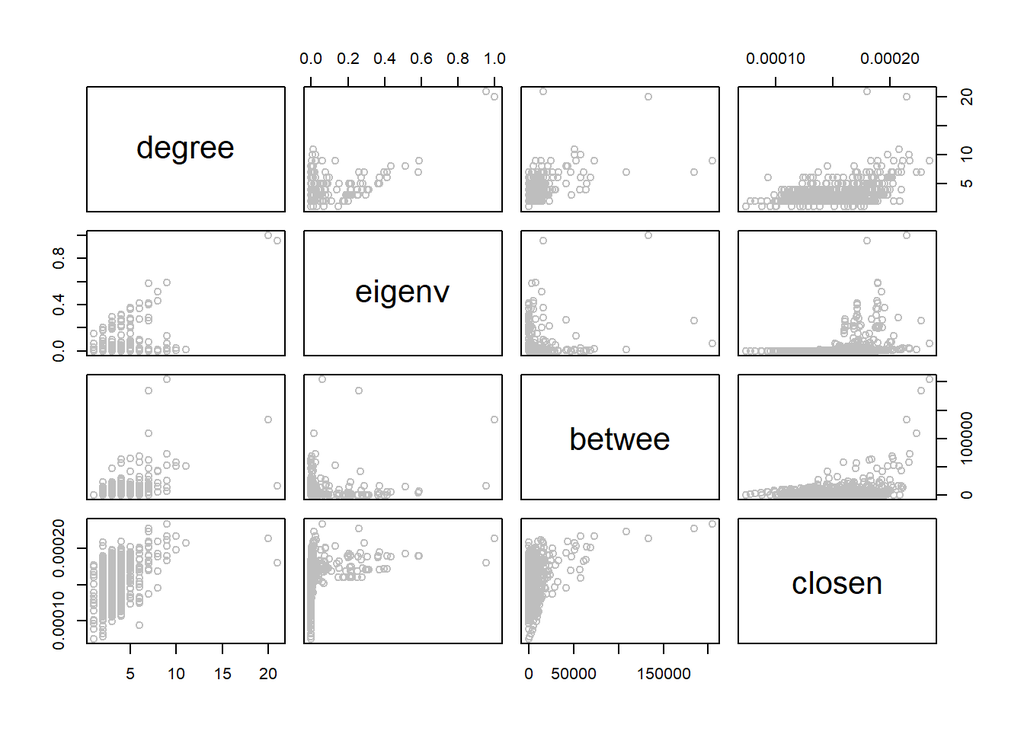

Network centrality measures ORBIS

```r
pairs(~degree+eigenv+betwee+closen, data=cmdf, col="gray")
```

Alternatively, we can add smoothers and univariate distributions to the scatterplot matrix with `car` package.

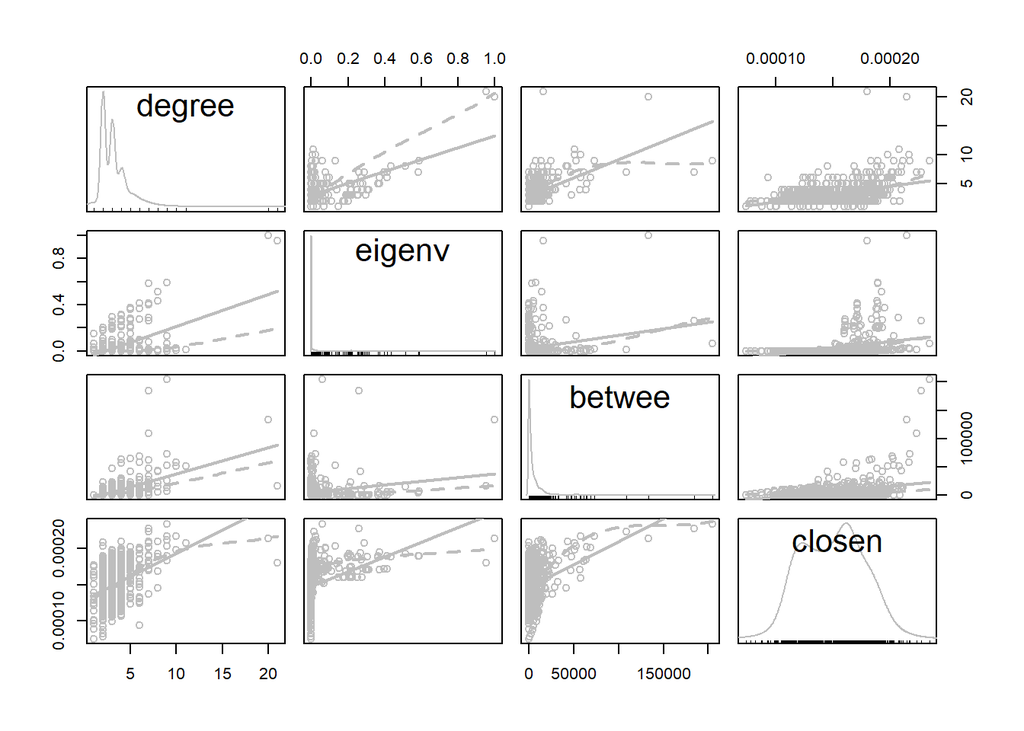

Network centrality measures ORBIS with trends

```r
car::spm(~degree+eigenv+betwee+closen, data=cmdf, col="gray", smooth=list(spread=FALSE))
```

## Valued networks

Recall that the relations in the ORBIS network are made with the travel expenses between cities (or crossing points), and this information was recorded in `orbise`.

```r
head(orbise[,c(1,2,5)])
```

```
  source target expense
1  50001  50056   1.909
2  50001  50100   1.755
3  50001  50293   2.299
4  50001  50473   7.888
5  50002  50275   3.226
6  50003  50052   3.820
```

Hence, for a valued or weighted version of this network, we create a valued edge list in `orbisv` with send, receive, and tie weights.

```r
orbisv <- orbise[,c(1,2,5)]
tail(orbisv)
```

```
     source target expense
2203  50800  50779   0.059
2204  50800  50783   0.056
2205  50801  50573   0.109
2206  50801  50582   0.074
2207  50801  50777   0.033
2208  50801  50785   0.034
```

We can see, however, that travel expenses are real values that can be decimals below 1. To avoid misscalculations, better to scale up the travel cost weights.

```r
orbisv[,3] <- orbisv[,3]*100
tail(orbisv)
```

```
     source target expense
2203  50800  50779     5.9
2204  50800  50783     5.6
2205  50801  50573    10.9
2206  50801  50582     7.4
2207  50801  50777     3.3
2208  50801  50785     3.4
```

#### Centrality measures in valued networks

Different centrality measures for weighted networks are found in `"tnet"` package where argument `alpha` is a tuning parameter that serves to combine node’s degree and edge’s strength. An alpha value of zero ignores edges’ weights; i.e. binarize the network, while an alpha value of one disregards nodes’ number of incident edges.

The following examples are for three centrality measures spliting equally node degree and edge strength in the weighted system.

```r
# degree centrality valued
tail(tnet::degree_w(net=orbisv, measure=c("degree","output","alpha"), alpha=0.5))
```

```
          node degree output     alpha
[50796,] 50796      3  127.0 19.519221
[50797,] 50797      2    8.0  4.000000
[50798,] 50798      2    6.1  3.492850
[50799,] 50799      2    9.5  4.358899
[50800,] 50800      4   16.5  8.124038
[50801,] 50801      4   25.0 10.000000
```

```r
# betweenness centrality valued
tail(tnet::betweenness_w(net=orbisv, alpha=0.5))
```

```
          node betweenness
[50796,] 50796        1352
[50797,] 50797           0
[50798,] 50798           0
[50799,] 50799           0
[50800,] 50800           0
[50801,] 50801         120
```

```r
# closeness centrality valued
tail(tnet::closeness_w(net=orbisv, alpha=0.5))
```

```
        node    closeness  n.closeness
[673,] 50796 1.298232e-04 1.917624e-07
[674,] 50797 9.325457e-05 1.377468e-07
[675,] 50798 7.390118e-05 1.091598e-07
[676,] 50799 1.105484e-04 1.632915e-07
[677,] 50800 7.850528e-05 1.159605e-07
[678,] 50801 9.979916e-05 1.474138e-07
```

#### Eigenvector centrality in valued networks

There is no support in `"tnet"` package to compute *eigenvector centrality* scores for valued networks. With an unclear documentation, `"igraph"` package has a `weights` argument in `eigen_centrality()` function to run eigenvector centrality for weighted networks. Since `"tnet"` requires `"igraph"`, however, the implementation of eigenvector centrality for valued networks is not straightforward.

¨

### See also

- [Plotting Roman Empire transport network](https://sdam-au.github.io/sdam/articles/TransportNetwork.html)
- [Plotting ancient Roman provinces and regions](https://sdam-au.github.io/sdam/articles/RomanProvs.html)
- [Re-encoding Greek characters from ‘EDH’ dataset](https://sdam-au.github.io/sdam/articles/Encoding.html)
- [`"sdam"` manual](https://github.com/mplex/cedhar/blob/master/typesetting/reports/sdam.pdf)
- [Social Dynamics and complexity in the Ancient Mediterranean Project](https://sdam-au.github.io/sdam-au/)